# 07 Plots

## Facets

We can also split our data into different facets, which creates plot panels based on groups in the data. Here is an example - the variable which the facets should be based on is provided after a little `~`:

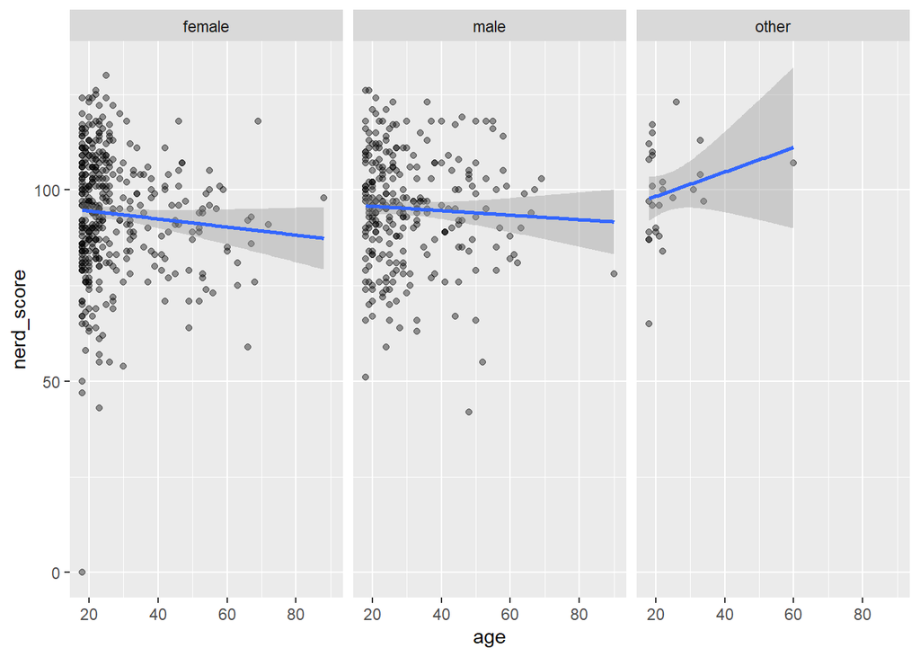

```r
nerd_red %>%
  ggplot(aes(x = age, y = nerd_score)) +
  geom_point(alpha = .4) +
  geom_smooth(method = "lm") +
  facet_wrap(~ gender)
```

You can also create facets based on two variables by specifying a variable on each side of the `~`:

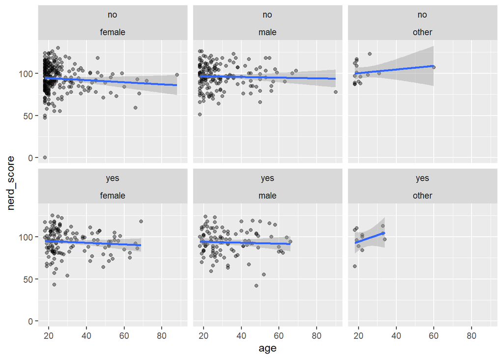

```r
nerd_red %>%
  ggplot(aes(x = age, y = nerd_score)) +
  geom_point(alpha = .4) +
  geom_smooth(method = "lm") +
  facet_wrap(voted ~ gender)
```

There is also the very similar `facet_grid()` function that basically does the same thing, but with a slightly different result:

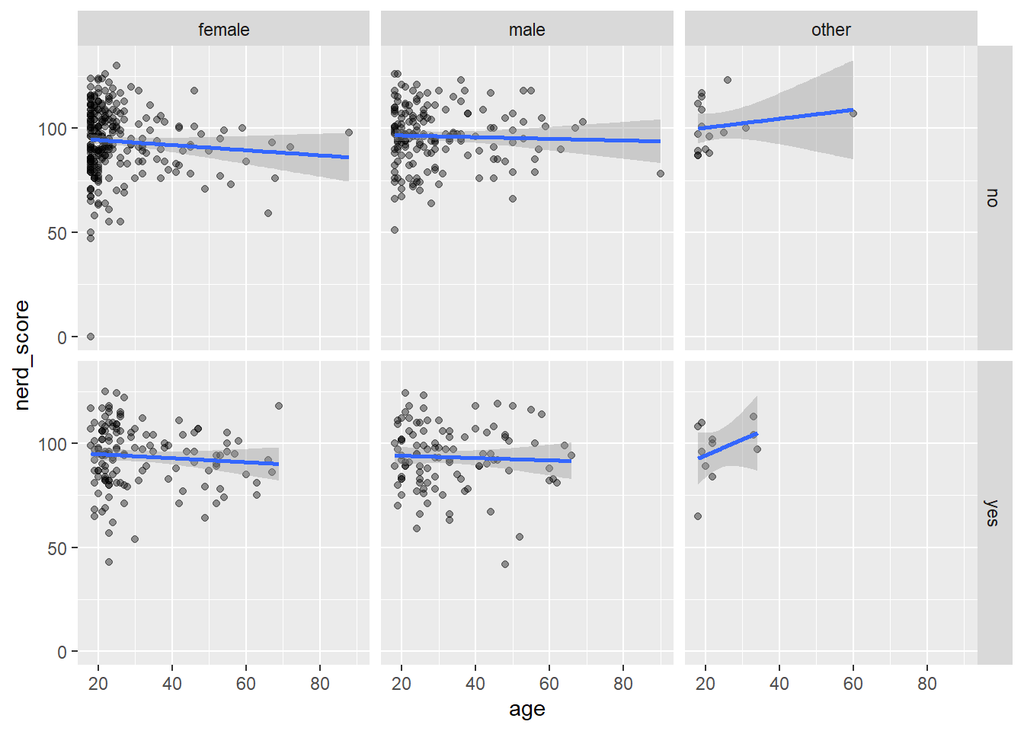

```r
nerd_red %>%
  ggplot(aes(x = age, y = nerd_score)) +
  geom_point(alpha = .4) +
  geom_smooth(method = "lm") +
  facet_grid(voted ~ gender)
```

6.1) Create a plot with facets yourself. Try to additionally add some aesthetics that are based on the data (i.e. that work inside of `aes()`).

### Optional

Earlier, we saw that `fill` controls the colour a geom (e.g. a boxplot) is filled with, while `colour` controls the colour of the outline. So, it seems odd that we use colour to control the **filling** of the points in a scatter plot. That is because by default, the scatter plot uses a shape (the points) that don’t have a filling. There are other shapes that have both a filling and a border. Compare the following examples:

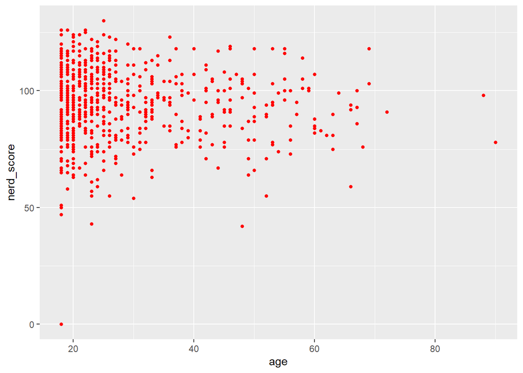

```r
nerd_red %>%
  ggplot(aes(x = age, y = nerd_score)) +
  geom_point(size = 2, colour = "red", fill = "green", shape = 20)
```

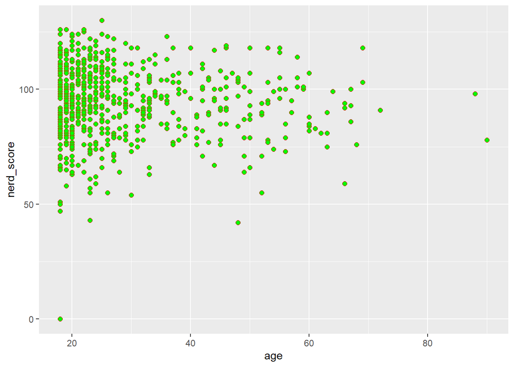

```r
nerd_red %>%
  ggplot(aes(x = age, y = nerd_score)) +
  geom_point(size = 2, colour = "red", fill = "green", shape = 21)
```

There are several different shapes that we can use in our scatter plot, and we address them by different numbers using the `shape` argument. [Here](http://www.sthda.com/english/wiki/ggplot2-point-shapes) is a list of all available shapes. Shapes 21 - 25 respond to `colour` **and** `fill`.

**THIS IS A GITHUB PUSH CHECKPOINT**